# CostCurves R-Package

#### **Full Options to plotting Cost Curves (CCtresholChoice function)**

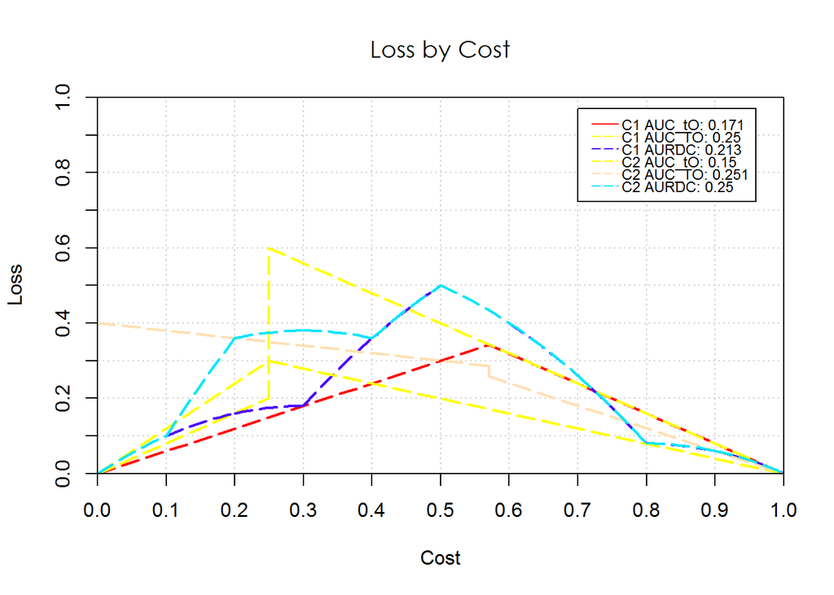

```r
R<-CCtresholdChoice(list(A, B), list(classes), cost_curves = FALSE, uniquec = TRUE, training_optimal = TRUE,    predictionsT =  list(B, A), classesT = list(classes), uniquecT = TRUE, rate_driven = TRUE)
```

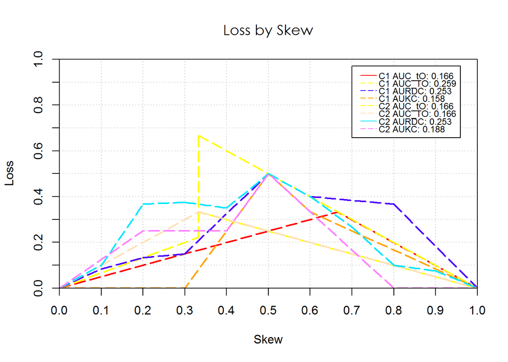

```r
R<-CCtresholdChoice(list(A, B), list(classes), cost_curves = FALSE, loss2skew = TRUE, uniquec = TRUE, training_optimal = TRUE, predictionsT =  list(B), classesT = list(classes), uniqueTraining = TRUE, kendall_curves = TRUE, rate_driven = TRUE)
```

## Description of features

### Functions to plot Cost Curves

- BrierCurves
- CCtresholdChoice
- CostCurves
- KendallCurves
- RateDrivenCurves
- RocCurves
- TestOptimal
- TrainingOptimal

### Graphics Options settings

| Parameter | Description |
| --- | --- |
| hold | The view is maintained to plot a new curve above the current curve. |
| plotOFF | Allow turn off plot. |
| gridOFF | Allow turn off grid. |
| pointsOFF | Allow turn off point marks. |
| legendOFF | Allow turn off legend. |
| main | It is used to specify a different title to default title. |
| xlab | It is used to specify a different x label to default x label. |
| ylab | It is used to specify a different y label to default y label. |
| namesClassifiers | An array with names of each classifier. |
| lwd | Line width. (array or single value). |
| lty | Line type. (array or single value). |
| col | Line color. (array or list of arrays). |
| pch | Point type. (array or single value). |
| cex | Size point. (array or single value). |
| xPosLegend | x coordinate to be used to position the legend. |
| yPosLegend | y coordinate to be used to position the legend. |
| cexL | Size Lengend. |

### General Options settings

Enabled for all graphical functions:

| Parameter | Description |
| --- | --- |
| predictions | A list of predictions or scores arrays. |
| classes | A list of classes arrays, each array represent binary classes. |
| loss2Skew | If it is TRUE, loss by Skew is plotted otherwise loss by cost is plotted. |
| uniquec | If it is TRUE, the same array classes is used for each array in a list predictions. |

### Specific Options settings

- Using only in CCtresholdChoice function:

| Parameter | Description |
| --- | --- |
| cost-curves | To plot cost curves. |
| test_optimal | To plot cost curves using test optimal treshold choice method. |
| training_optimal | To plot cost curves using training optimal treshold choice method. |
| predictionsT | A list of classes arrays, each array represent predictions or scores of training classifier. -Only for training optimal option- |
| classesT | A list of classes arrays, each array represent binary classes training. -Only for training optimal option- |
| uniquecT | If it is TRUE, the same array classes is used for each array in a list predictions training. -Only for training optimal option- |
| uniqueTraining | If it is TRUE, the same array of predictionsT and classesT is used for each array in a list predictions. -Only for training optimal- option_ |
| score_driven | To plot cost curves using score driven treshold choice method. |
| rate_driven | To plot cost curves using rate driven treshold choice method. |
| kendall_curves | To plot cost curves using kendall driven treshold choice method. |

- Using only in TrainingOptimal function:

| Parameter | Description |
| --- | --- |
| predictions_training | A list of predictions arrays, each array represent scores of a specific classifier training. |
| classes_training | A list of classes arrays, each array represent binary classes of training. |
| predictions_test | A list of predictions arrays, each array represent scores test. |
| classes_test | A list of classes arrays, each array represent binary classes test. |
| uniquecT | If it is TRUE, the same array classes is used for each array in a list predictions Training. |
| uniquect | If it is TRUE, the same array classes is used for each array in a list predictions test. |
| refuseT | It is possible to use the same training classifier for every test. |

## References:

- Drummond, C., & Holte, R. C. (2006). Cost curves: An improved method for visualizing classifier performance.
- Fawcett, T. (2006). An introduction to ROC analysis. Pattern recognition letters, 27(8), 861-874.
- Ferri, C., Hernandez-orallo, J., & Flach, P. A. (2011). Brier curves: a new cost-based visualisation of classifier performance. In Proceedings of the 28th International Conference on Machine Learning (ICML-11) (pp. 585-592).
- Hernandez-Orallo, J., Flach, P., & Ferri, C. (2013). ROC curves in cost space. Machine learning, 93(1), 71-91.